# Phase 1a CFA - RMARS

Jenny Terry

10/06/2020

First, read in the cleaned, anonymised data.

```r
# read in anonymised data file
statanx_data <- readr::read_csv(here::here("data", "anon_data.csv"))
# check first few rows
head(statanx_data)
```

```
## # A tibble: 6 x 157
##   id    q4.1_1 q4.1_2 q4.1_3 q4.1_4 q4.1_5 q4.1_6 q4.1_7 q4.1_8 q4.1_9 q4.1_10
##   <chr>  <dbl>  <dbl>  <dbl>  <dbl>  <dbl>  <dbl>  <dbl>  <dbl>  <dbl>   <dbl>
## 1 jroWw      5      3      2      3      3      3      3      5      1       4
## 2 DMP8X      2      1      1      1      1      1      2      1      1       1
## 3 Jebht      3      3      2      3      4      3      5      5      1       5
## 4 1W4o3      4      2      4      5      4      3      5      5      3       5
## 5 fdzgn      4      3      3      2      3      2      4      4      1       3
## 6 Trng5      5      5      5      5      4      5      5      5      2       5
## # ... with 146 more variables: q4.1_11 <dbl>, q4.1_12 <dbl>, q4.1_13 <dbl>,
## #   q4.1_14 <dbl>, q4.1_15 <dbl>, q4.1_16 <dbl>, q4.1_17 <dbl>, q4.1_18 <dbl>,
## #   q4.1_19 <dbl>, q4.1_20 <dbl>, q4.1_21 <dbl>, q4.1_22 <dbl>, q4.1_23 <dbl>,
## #   q4.2_1 <dbl>, q4.2_2 <dbl>, q4.2_3 <dbl>, q4.2_4 <dbl>, q4.2_5 <dbl>,
## #   q4.2_6 <dbl>, q4.2_7 <dbl>, q4.2_8 <dbl>, q4.2_9 <dbl>, q4.2_10 <dbl>,
## #   q4.2_11 <dbl>, q4.2_12 <dbl>, q4.2_13 <dbl>, q4.2_14 <dbl>, q4.2_15 <dbl>,
## #   q4.2_16 <dbl>, q4.2_17 <dbl>, q4.2_18 <dbl>, q4.2_19 <dbl>, q4.2_20 <dbl>,
## #   q4.3_1 <dbl>, q4.3_2 <dbl>, q4.3_3 <dbl>, q4.3_4 <dbl>, q4.3_5 <dbl>,
## #   q4.3_6 <dbl>, q4.3_7 <dbl>, q4.3_8 <dbl>, q4.3_9 <dbl>, q4.3_10 <dbl>,
## #   q4.3_11 <dbl>, q4.3_12 <dbl>, q4.3_13 <dbl>, q4.3_14 <dbl>, q4.3_15 <dbl>,
## #   q4.3_16 <dbl>, q4.3_17 <dbl>, q4.3_18 <dbl>, q4.3_19 <dbl>, q4.3_20 <dbl>,
## #   q4.4_1 <dbl>, q4.4_2 <dbl>, q4.4_3 <dbl>, q4.4_4 <dbl>, q4.4_5 <dbl>,
## #   q4.4_6 <dbl>, q4.4_7 <dbl>, q4.4_8 <dbl>, q4.4_9 <dbl>, q4.4_10 <dbl>,
## #   q4.4_11 <dbl>, q4.4_12 <dbl>, q4.4_13 <dbl>, q4.4_14 <dbl>, q4.4_15 <dbl>,
## #   q4.4_16 <dbl>, q4.4_17 <dbl>, q4.4_18 <dbl>, q4.4_19 <dbl>, q5.1_1 <dbl>,
## #   q5.1_2 <dbl>, q5.1_3 <dbl>, q5.1_4 <dbl>, q5.1_5 <dbl>, q5.1_6 <dbl>,
## #   q5.1_7 <dbl>, q5.1_8 <dbl>, q5.1_9 <dbl>, q5.1_10 <dbl>, q5.1_11 <dbl>,
## #   q5.1_12 <dbl>, q5.1_13 <dbl>, q5.1_14 <dbl>, q5.1_15 <dbl>, q5.1_16 <dbl>,
## #   q5.1_17 <dbl>, q5.1_18 <dbl>, q5.1_19 <dbl>, q5.1_20 <dbl>, q5.1_21 <dbl>,
## #   q5.2_1 <dbl>, q5.2_2 <dbl>, q5.2_3 <dbl>, q5.2_4 <dbl>, q5.2_5 <dbl>,
## #   q5.2_6 <dbl>, q5.2_7 <dbl>, ...
```

```r
# prepare dataset for factor analysis
rmars_data <- statanx_data %>% dplyr::select(., q4.3_1:q4.3_20)

# check dataset
head(rmars_data)
```

```
## # A tibble: 6 x 20
##   q4.3_1 q4.3_2 q4.3_3 q4.3_4 q4.3_5 q4.3_6 q4.3_7 q4.3_8 q4.3_9 q4.3_10 q4.3_11
##    <dbl>  <dbl>  <dbl>  <dbl>  <dbl>  <dbl>  <dbl>  <dbl>  <dbl>   <dbl>   <dbl>
## 1      4      5      4      5      3      4      5      4      4       5       1
## 2      1      1      1      1      1      1      1      1      1       1       1
## 3      4      5      3      4      4      5      5      3      5       5       1
## 4      4      4      4      4      3      3      2      4      4       5       1
## 5      4      4      4      4      2      3      3      3      4       3       1
## 6      5      5      5      5      5      5      5      5      5       5       1
## # ... with 9 more variables: q4.3_12 <dbl>, q4.3_13 <dbl>, q4.3_14 <dbl>,
## #   q4.3_15 <dbl>, q4.3_16 <dbl>, q4.3_17 <dbl>, q4.3_18 <dbl>, q4.3_19 <dbl>,
## #   q4.3_20 <dbl>
```

```r
rmars_data %<>%
  dplyr::rename(
    rmars_test1 = q4.3_1,
    rmars_test2 = q4.3_2,
    rmars_test3 = q4.3_3,
    rmars_test4 = q4.3_4,
    rmars_test5 = q4.3_5,
    rmars_test6 = q4.3_6,
    rmars_test7 = q4.3_7,
    rmars_test8 = q4.3_8,
    rmars_test9 = q4.3_9,
    rmars_test10 = q4.3_10,
    rmars_num1 = q4.3_11,
    rmars_num2 = q4.3_12,
    rmars_num3 = q4.3_13,
    rmars_num4 = q4.3_14,
    rmars_num5 = q4.3_15,
    rmars_course1 = q4.3_16,
    rmars_course2 = q4.3_17,
    rmars_course3 = q4.3_18,
    rmars_course4 = q4.3_19,
    rmars_course5 = q4.3_20
    )
```

```r
# specify measurement model), e.g.:
rmars_mod <- 'test =~ rmars_test1 + rmars_test2 + rmars_test3 + rmars_test4 + rmars_test5 + rmars_test6 +                         rmars_test7 + rmars_test8 + rmars_test9 + rmars_test10
              num =~ rmars_num1 + rmars_num2 + rmars_num3 + rmars_num4 + rmars_num5
              course =~ rmars_course1 + rmars_course2 + rmars_course3 + rmars_course4 + rmars_course5'
```

Next, the model will be fitted using the MLR estimator that uses robust (Huber-White) standard errors and a scaled test statistic that is (asymptotically) equal to the Yuan-Bentler test statistic, and FIML to handle missing data.

By default, lavaan constrains each latent factor’s scale to that of its first observed variable but, because this means no coefficient would be obtained for these indicators, the latent factors will instead be standardised (giving them a mean of zero and a variance of one) by calling `std.lv = TRUE`.

```r
# fit the model
rmars_out <- lavaan::cfa(rmars_mod, data = rmars_data, estimator = "MLR", missing = "fiml.x", std.lv = TRUE)

# display model output
lavaan::summary(rmars_out, standardized = TRUE, fit.measures = TRUE, rsq = TRUE)
```

```
## lavaan 0.6-7 ended normally after 22 iterations
##
##   Estimator                                         ML
##   Optimization method                           NLMINB
##   Number of free parameters                         63
##
##   Number of observations                           465
##   Number of missing patterns                         1
##
## Model Test User Model:
##                                                Standard      Robust
##   Test Statistic                                638.193     564.344
##   Degrees of freedom                                167         167
##   P-value (Chi-square)                            0.000       0.000
##   Scaling correction factor                                   1.131
##        Yuan-Bentler correction (Mplus variant)
##
## Model Test Baseline Model:
##
##   Test statistic                              6228.585    5300.119
##   Degrees of freedom                               190         190
##   P-value                                        0.000       0.000
##   Scaling correction factor                                  1.175
##
## User Model versus Baseline Model:
##
##   Comparative Fit Index (CFI)                    0.922       0.922
##   Tucker-Lewis Index (TLI)                       0.911       0.912
##
##   Robust Comparative Fit Index (CFI)                         0.925
##   Robust Tucker-Lewis Index (TLI)                            0.915
##
## Loglikelihood and Information Criteria:
##
##   Loglikelihood user model (H0)             -11377.691  -11377.691
##   Scaling correction factor                                  1.169
##       for the MLR correction
##   Loglikelihood unrestricted model (H1)     -11058.595  -11058.595
##   Scaling correction factor                                  1.141
##       for the MLR correction
```

[output cut: 119 more lines]

```
##     rmars_test6       0.682
##     rmars_test7       0.668
##     rmars_test8       0.461
##     rmars_test9       0.451
##     rmars_test10      0.582
##     rmars_num1        0.225
##     rmars_num2        0.649
##     rmars_num3        0.704
##     rmars_num4        0.731
##     rmars_num5        0.679
##     rmars_course1     0.320
##     rmars_course2     0.606
##     rmars_course3     0.568
##     rmars_course4     0.567
##     rmars_course5     0.496
```

Then, obtain the fit measures and other statistics that will be interpreted (some repeat those obtained in the summary above but I like to print them like this as well for ease of reference).

```r
# print table of fit measures
lavaan::fitMeasures(rmars_out, c("chisq","df","pvalue", "cfi", "tli", "rmsea", "srmr"))
```

```
##   chisq      df  pvalue     cfi     tli   rmsea    srmr
## 638.193 167.000   0.000   0.922   0.911   0.078   0.060
```

```r
# print standardised residuals
lavaan::resid(rmars_out, type = "standardized")
```

```
## $type
## [1] "standardized"
##
## $cov
##               rmrs_t1 rmrs_t2 rmrs_t3 rmrs_t4 rmrs_t5 rmrs_6 rmrs_7 rmrs_8
## rmars_test1    0.000
## rmars_test2   -1.296   0.000
## rmars_test3   -0.491   0.886   0.000
## rmars_test4   -2.997   0.890   1.329   0.000
## rmars_test5    1.978  -1.436  -1.974  -1.686   0.000
## rmars_test6    0.334  -2.140  -0.846   0.081   3.970   0.000
## rmars_test7   -2.443  -0.463  -0.797   1.533   0.318   2.973  0.000
## rmars_test8    3.042   0.915  -0.540  -3.098   0.121  -1.621 -2.498  0.000
## rmars_test9   -0.989   0.822   0.850   4.102  -4.158  -2.579  0.922 -1.871
## rmars_test10  -2.210   1.848   1.434   1.307  -3.407  -1.722  1.017 -0.547
## rmars_num1     0.320  -0.626  -2.172  -3.373  -1.357  -2.763 -3.441  0.753
## rmars_num2     3.308   1.376   2.431  -1.594   1.609  -0.277 -1.312  4.286
## rmars_num3     2.275  -0.709  -0.535  -4.247   0.717  -3.154 -3.474  3.285
## rmars_num4     2.882   1.390   2.192  -2.856   1.307  -1.243 -2.143  4.785
## rmars_num5     2.178   0.098   1.559  -1.531   1.356   0.088  0.046  3.787
## rmars_course1  0.966  -2.983  -2.412  -4.445  -0.078  -2.584 -3.375  1.552
## rmars_course2  2.736  -0.171  -0.721  -3.549  -0.020  -2.613 -2.479  5.062
## rmars_course3  6.361   0.981   0.882  -1.254   2.965   1.072  0.022  9.544
## rmars_course4  4.444  -1.121  -0.875  -3.106   1.694  -2.098 -2.262  4.772
## rmars_course5  3.064   0.027   0.706  -1.153   0.877   0.474 -0.576  5.558
##               rmrs_9 rmr_10 rmrs_n1 rmrs_n2 rmrs_n3 rmrs_n4 rmrs_n5 rmrs_c1
## rmars_test1
## rmars_test2
## rmars_test3
## rmars_test4
## rmars_test5
## rmars_test6
## rmars_test7
## rmars_test8
## rmars_test9    0.000
## rmars_test10   1.342  0.000
## rmars_num1    -2.183 -2.363  0.000
## rmars_num2    -0.164  1.232  0.129   0.000
## rmars_num3    -1.265 -2.165  0.709   0.638   0.000
## rmars_num4    -1.231  0.913  0.562  -0.540  -0.222   0.000
```

[output cut: 22 more lines]

```
## rmars_course1
## rmars_course2  0.000
## rmars_course3 -0.729   0.000
## rmars_course4  1.693  -0.651   0.000
## rmars_course5 -1.040   1.001  -1.657   0.000
##
## $mean
##   rmars_test1   rmars_test2   rmars_test3   rmars_test4   rmars_test5
##             0             0             0             0             0
##   rmars_test6   rmars_test7   rmars_test8   rmars_test9  rmars_test10
##             0             0             0             0             0
##    rmars_num1    rmars_num2    rmars_num3    rmars_num4    rmars_num5
##             0             0             0             0             0
## rmars_course1 rmars_course2 rmars_course3 rmars_course4 rmars_course5
##             0             0             0             0             0
```

```r
# print modification indices above 4, sorted by size
lavaan::modindices(rmars_out, sort. = TRUE, minimum.value = 3.86)
```

```
##               lhs op           rhs     mi    epc sepc.lv sepc.all sepc.nox
## 102        course =~   rmars_test8 86.406  0.768   0.768    0.586    0.586
## 95         course =~   rmars_test1 60.047  0.475   0.475    0.438    0.438
## 180   rmars_test5 ~~   rmars_test6 54.419  0.199   0.199    0.389    0.389
## 87            num =~   rmars_test8 37.854  0.395   0.395    0.301    0.301
## 168   rmars_test4 ~~   rmars_test9 33.631  0.148   0.148    0.294    0.294
## 98         course =~   rmars_test4 32.417 -0.323  -0.323   -0.310   -0.310
## 195   rmars_test6 ~~   rmars_test7 31.702  0.125   0.125    0.310    0.310
## 116   rmars_test1 ~~   rmars_test8 31.078  0.188   0.188    0.281    0.281
## 231   rmars_test8 ~~ rmars_course3 25.748  0.211   0.211    0.261    0.261
## 295 rmars_course2 ~~ rmars_course4 22.673  0.162   0.162    0.293    0.293
## 80            num =~   rmars_test1 22.357  0.225   0.225    0.207    0.207
## 259    rmars_num1 ~~ rmars_course1 20.667  0.125   0.125    0.219    0.219
## 83            num =~   rmars_test4 20.585 -0.199  -0.199   -0.192   -0.192
## 101        course =~   rmars_test7 18.005 -0.240  -0.240   -0.220   -0.220
```

[output cut: 43 more lines]

```r
# print table of parameter estimates (for ease of reference)
lavaan::parameterEstimates(rmars_out, standardized = TRUE)
```

```
##              lhs op           rhs   est    se      z pvalue ci.lower ci.upper
## 1           test =~   rmars_test1 0.831 0.039 21.379      0    0.755    0.907
## 2           test =~   rmars_test2 0.870 0.042 20.932      0    0.789    0.951
## 3           test =~   rmars_test3 0.987 0.037 26.660      0    0.914    1.059
## 4           test =~   rmars_test4 0.820 0.041 20.024      0    0.739    0.900
## 5           test =~   rmars_test5 0.869 0.042 20.776      0    0.787    0.950
## 6           test =~   rmars_test6 0.939 0.036 26.025      0    0.869    1.010
## 7           test =~   rmars_test7 0.892 0.037 23.975      0    0.819    0.965
## 8           test =~   rmars_test8 0.890 0.047 19.046      0    0.798    0.982
## 9           test =~   rmars_test9 0.714 0.046 15.474      0    0.624    0.804
## 10          test =~  rmars_test10 0.852 0.041 20.903      0    0.772    0.932
## 11           num =~    rmars_num1 0.378 0.050  7.554      0    0.280    0.476
## 12           num =~    rmars_num2 0.925 0.044 20.840      0    0.838    1.012
## 13           num =~    rmars_num3 0.846 0.051 16.493      0    0.746    0.947
## 14           num =~    rmars_num4 0.970 0.044 22.263      0    0.885    1.056
```

[output cut: 125 more lines]

Finally, draw a plot of the model (will need adapting for model with real data).

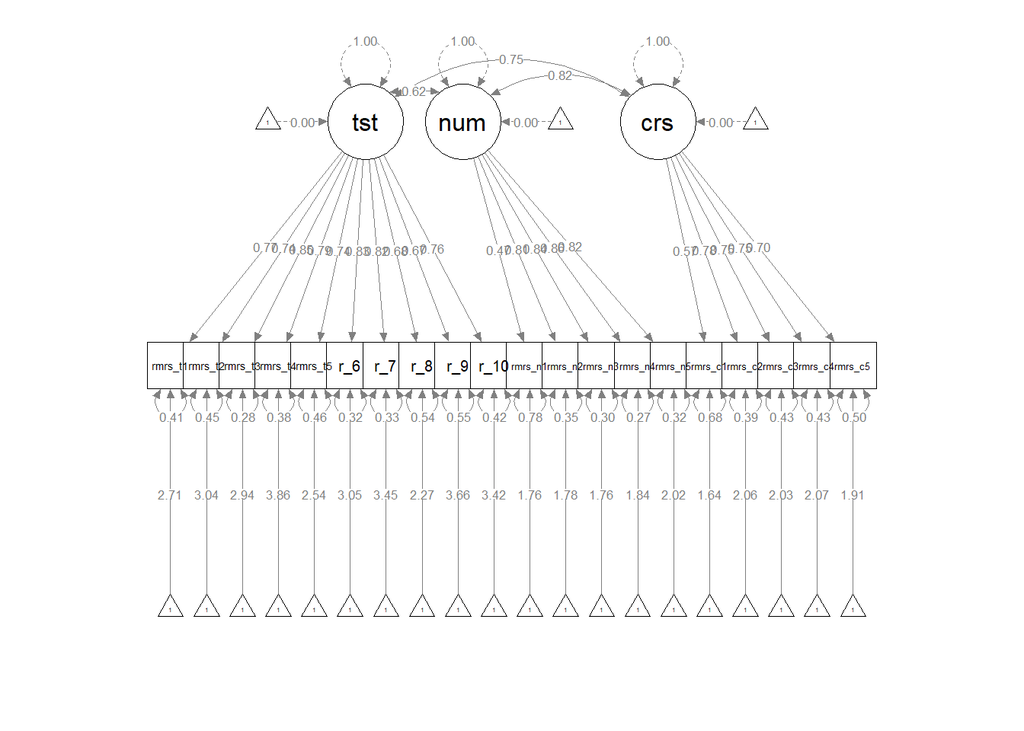

```r
# plot CFA model
semPlot::semPaths(rmars_out, whatLabels = "std")
```